# Feed-microbiome-host interactions in Atlantic salmon over life stages

Low dosage of betamannan

Shashank Gupta

2023-02-03

## Step 1. Transcriptomics (Liver)

### Load packages

```r
library("stringr")
library("dplyr")
library("DESeq2")
library("ggplot2")
library("tibble")
library("AnnotationHub")
library("AnnotationDbi")
library("readr")
library("dplyr")
library("clusterProfiler")
library("GenomicFeatures")
library("GO.db")
library("BiocParallel")
library("DT")
library("WGCNA")
library("cowplot")
library("gridExtra")
library("EnhancedVolcano")
library("plyr")
```

Set seed as a precaution for reproducibility as some methods are non-deterministic.

```r
set.seed(13118)
Run_analysis <- TRUE    # if FALSE it tries to load data instead of running the module creation step.
prefix <- "h"
save_TOM <- FALSE       # Can get rather big
pam_stage <- FALSE      # Partitioning around medoids, tries to put more genes into modules where it is not directly clear from the dendrogram cutting.
set_verbose = 1         # How much detail from the WGCNA functions? A higher number means more detail.
assoc_measure = "bicor"
plot_labeling_size = 15
theme_set(theme_bw())
```

### Import data

Loop to read in the raw count files and store them in a list

```r
rawCounts_list <- list()
for (i in 1:4) {
  file_path <- paste0("~/Desktop/salmon_project/Gene_Counts/featurecounts_X204SC21043349-Z02-F001_", i, "_genome")
  rawCounts_list[[i]] <- read.delim(file_path)
}

rawCounts_total <- join_all(rawCounts_list, by = 'Geneid', type = 'full')
```

Loop to simplify the code for removing unnecessary information from column names:

```r
patterns_to_remove <- c(
  "X.home.projects.ku.cbd.data.HoloFish.IMPROVAFISH.ANALYSES_HostRNA.5_star_2pass.X204SC21043349.Z02.F001_1.",
  "X.home.projects.ku.cbd.data.HoloFish.IMPROVAFISH.ANALYSES_HostRNA.5_star_2pass.X204SC21043349.Z02.F001_2.",
  "X.home.projects.ku.cbd.data.HoloFish.IMPROVAFISH.ANALYSES_HostRNA.5_star_2pass.X204SC21043349.Z02.F001_3.",
  "X.home.projects.ku.cbd.data.HoloFish.IMPROVAFISH.ANALYSES_HostRNA.5_star_2pass.X204SC21043349.Z02.F001_4.",
  "_Aligned.sortedByCoord.out.bam",
  "\\..*"
)

for (pattern in patterns_to_remove) {
  colnames(rawCounts_total) <- gsub(pattern, "", colnames(rawCounts_total))
}
```

Loop to remove columns containing specific strings:

```r
columns_to_remove <- c("Chr", "Start", "End", "BLK", "CL1", "CP1", "CP2", "CP3")

column_indices_to_remove <- which(names(rawCounts_total) %in% columns_to_remove)

rawCounts_total <- rawCounts_total[, -column_indices_to_remove]
rawCounts_total <- data.frame(rawCounts_total[, -1], row.names = rawCounts_total[, 1])
```

Finally, for renaming row and column names. Also main idea of this chunk of code is make sure we have same number of samples in `countData` and samples in `colData` for `DESeq2`. Also the order of the samples in `colData` need to match the order of the samples in `countData`

```r
mapping_file <- read.table("~/Desktop/salmon_project/SampleData.txt", header = T, sep = "\t", row.names = 1)
mapping_file <- subset(mapping_file, !Sample_Type %in% c("BLK" ,"CL1", "CP1", "CP2", "CP3", "Gills", "Hind_Gut"))
mapping_file$New_Diet <- toupper(mapping_file$New_Diet)
mapping_file$common <- rownames(mapping_file)
mapping_file$common <- gsub("_Lh0", "_", mapping_file$common)
rownames(mapping_file) <- mapping_file$common
colnames(rawCounts_total) <- gsub("_Lh0", "_", colnames(rawCounts_total))


rows_to_remove <- c("T0")
mapping_file <- mapping_file[!mapping_file$Time %in% rows_to_remove,]
rawCounts_total <- rawCounts_total[, !grepl("T0_ctr_", names(rawCounts_total))]

reorder_idx <- match(rownames(mapping_file), colnames(rawCounts_total))
rawCounts_total <- rawCounts_total[, reorder_idx]
all(colnames(rawCounts_total) == rownames(mapping_file))
```

```
## [1] TRUE
```

```r
omics_data_host_Liver <- rawCounts_total
sample_info <- mapping_file
sample_info$common <- rownames(sample_info)
```

```r
#sample_info$New_Diet <- tolower(sample_info$New_Diet)
#Rename the sample names based on new diet
sample_info$ID_New <- paste(sample_info$Time, "_",
                            sample_info$New_Diet, "_",
                            sample_info$Tank_number, "_", "0",
                            sample_info$Sample_Number,
                                      sep = "")
head_change <- subset(sample_info, select=c("common" ,"ID_New"))
row.names(sample_info) <- sample_info$ID_New

omics_data_host_Liver1 <- omics_data_host_Liver[, colnames(omics_data_host_Liver) %in% sample_info$common]
omics_data_host_Liver <- omics_data_host_Liver1
all(colnames(omics_data_host_Liver) == sample_info$common)
```

```
## [1] TRUE
```

```r
# rename colnames of omics_data_host_Liver using new ID
df1 <- subset(sample_info, select= c("common", "ID_New"))
new_colnames <- df1$ID_New[match(colnames(omics_data_host_Liver), df1$common)]
colnames(omics_data_host_Liver) <- ifelse(is.na(new_colnames), colnames(omics_data_host_Liver), new_colnames)
all(colnames(omics_data_host_Liver) == sample_info$ID_New)
```

```
## [1] TRUE
```

```r
df <- round(omics_data_host_Liver) %>%
  # The next steps require a data frame and round() returns a matrix
  as.data.frame() %>%
  # Only keep rows that have total counts above the cutoff
  dplyr::filter(rowSums(.) >= 50000)

all(colnames(df) == rownames(sample_info))
```

```
## [1] TRUE
```

```r
dds_liver <- DESeqDataSetFromMatrix(
  countData = df, # Our prepped data frame with counts
  colData = sample_info, # Data frame with annotation for our samples
  design = ~1 # Here we are not specifying a model
)
```

```r
dds_liver$group <- factor(paste0(dds_liver$Time, dds_liver$New_Diet))
design(dds_liver) <- ~ group-1

dds_liver <- DESeq(dds_liver, parallel = T)
resultsNames(dds_liver)
```

```
##  [1] "groupT1CTR" "groupT1MC1" "groupT1MC2" "groupT1MN3" "groupT2CTR"
##  [6] "groupT2MC1" "groupT2MC2" "groupT2MN3" "groupT3CTR" "groupT3MC1"
## [11] "groupT3MC2" "groupT3MN3"
```

```r
annot_function <- read_tsv("/Users/shashankgupta/Desktop/ImprovAFish/Salmo_salar-GCA_905237065.2_gene_annotations.tsv")
annot_function <- annot_function[, c("gene_id", "v2.gene_id.NCBI","v2.gene_name.ensembl", "v2.product")]
```

#### Time point 1 (T1)

##### Diet 1

```r
res <- results(dds_liver,
               contrast = list("groupT1MC1","groupT1CTR"))
table(res$padj < 0.05)
```

```
##
## FALSE  TRUE
##  5225    56
```

```r
res_tbl <- as_tibble(res, rownames = "ENSEMBL") %>%
  filter(padj <0.05)%>%
  arrange(padj)

res_tbl <- merge(res_tbl, annot_function, by.x = "ENSEMBL", by.y = "gene_id", all.x = TRUE )
DT::datatable(res_tbl)
```

|  | ENSEMBL | baseMean | log2FoldChange | lfcSE | stat | pvalue | padj | v2.gene_id.NCBI | v2.gene_name.ensembl | v2.product |
| --- | --- | --- | --- | --- | --- | --- | --- | --- | --- | --- |
| 1 | ENSSSAG00000000909 | 399.355066349054 | 1.19309513188213 | 0.266057054253476 | 4.48435819613884 | 7.31337215987409e-06 | 0.0055174169108993 | 106585868 | MDHC | malate dehydrogenase, cytoplasmic-like isoform X1 |
| 2 | ENSSSAG00000002210 | 1150.15583231301 | 0.938612930549021 | 0.266116175017292 | 3.52707959404583 | 0.000420170433303271 | 0.0410911121902699 | 106608372 | iyd | iodotyrosine dehalogenase 1 |
| 3 | ENSSSAG00000003802 | 1004.4247315419 | 1.79921771316667 | 0.489221233561996 | 3.6777179519921 | 0.000235329969321134 | 0.0296154193852023 | 100136522 | aldob | fructose-bisphosphate aldolase B |
| 4 | ENSSSAG00000004542 | 1013.86013775257 | 1.00709957634635 | 0.230581767443583 | 4.36764618257495 | 1.25592734156556e-05 | 0.00599336275031708 | 106600830 | AT5G3 | ATP synthase F(0) complex subunit C3, mitochondrial-like |
| 5 | ENSSSAG00000007114 | 68745.9313227872 | -1.58975636400979 | 0.364158563501925 | -4.36556083899806 | 1.26797003235667e-05 | 0.00599336275031708 | 106608805 | si:ch1073-126c3.2 | uncharacterized protein LOC106608805 |
| 6 | ENSSSAG00000007510 | 977.9361492859 | 1.70432253791573 | 0.455794481113891 | 3.73923469575723 | 0.000184581337893226 | 0.0270770568170591 | 106574916 | TCTP | translationally-controlled tumor protein homolog |
| 7 | ENSSSAG00000007561 | 4164.35443099304 | 0.77802394207728 | 0.191027571968986 | 4.07283584279444 | 4.6444159802443e-05 | 0.0113739449452355 | 100194703 |  | transposase-like |
| 8 | ENSSSAG00000007692 | 530.905000255548 | 0.994813239617938 | 0.279261083347832 | 3.56230530832273 | 0.000367612513723802 | 0.037879822326896 | 100196272 |  | 60S ribosomal protein L23a |
| 9 | ENSSSAG00000008630 | 3800.27810132339 | 1.33459849373423 | 0.339010689756934 | 3.93674457490152 | 8.2594437717268e-05 | 0.0166655480519434 | 106577194 | RS9 | 40S ribosomal protein S9 |
| 10 | ENSSSAG00000009700 | 487.305897926099 | 0.87775988949857 | 0.235218498609871 | 3.73167882069686 | 0.000190207916546854 | 0.0271483245211875 | 100217364 | oaz1s | ornithine decarboxylase antizyme 1S |

[output cut: 46 more lines]

```r
# res_tbl %>%
#   filter(log2FoldChange > 0) %>%
#   select(v2.product)
# length(res_tbl$log2FoldChange[res_tbl$log2FoldChange>0]) # count positive elements
# length(res_tbl$log2FoldChange[res_tbl$log2FoldChange<0]) # count negative elements
```

##### Diet 2

```r
res <- results(dds_liver,
               contrast = list("groupT1MC2","groupT1CTR"))
table(res$padj < 0.05)
```

```
##
## FALSE  TRUE
##  5274     7
```

```r
res_tbl <- as_tibble(res, rownames = "ENSEMBL") %>%
  filter(padj <0.05)%>%
  arrange(padj)
res_tbl <- merge(res_tbl, annot_function, by.x = "ENSEMBL", by.y = "gene_id", all.x = TRUE )
DT::datatable(res_tbl)
```

|  | ENSEMBL | baseMean | log2FoldChange | lfcSE | stat | pvalue | padj | v2.gene_id.NCBI | v2.gene_name.ensembl | v2.product |
| --- | --- | --- | --- | --- | --- | --- | --- | --- | --- | --- |
| 1 | ENSSSAG00000007114 | 68745.9313227872 | -1.69955768340305 | 0.364159196112298 | -4.66707336117621 | 3.05520268501716e-06 | 0.0040336313448939 | 106608805 | si:ch1073-126c3.2 | uncharacterized protein LOC106608805 |
| 2 | ENSSSAG00000039375 | 11751.6833590825 | -4.81216690229728 | 0.574529306638761 | -8.37584235772146 | 5.48302652290638e-17 | 2.89558630674686e-13 | 106604697 | mmp17b | matrix metalloproteinase-17-like |
| 3 | ENSSSAG00000046715 | 3286.91156237181 | -1.07250894509923 | 0.258374857690371 | -4.15098030313963 | 3.31054258760431e-05 | 0.0291382923418973 | 100380849 | mtor | serine/threonine-protein kinase mTOR isoform X2 |
| 4 | ENSSSAG00000048772 | 19721.5634070399 | -1.33495799764059 | 0.25246857723674 | -5.2876203932056 | 1.23917801479109e-07 | 0.000327204954805588 | 106609001 | cbln11 | complement C1q-like protein 2 |
| 5 | ENSSSAG00000070419 | 711.652588908885 | -1.36477596401139 | 0.324088066327243 | -4.21112686893362 | 2.54099984858438e-05 | 0.0268380404007483 | 106583199 | SEC61A1 | protein transport protein Sec61 subunit alpha isoform B-like |
| 6 | ENSSSAG00000091466 | 4798.64092648054 | -2.04806266409655 | 0.507690585345941 | -4.03407650882672 | 5.48174563537044e-05 | 0.0413558552862733 | 106594032 |  | haptoglobin-like |
| 7 | ENSSSAG00000113880 | 8951.75713813917 | -2.63180562006757 | 0.512550138301387 | -5.13472814345439 | 2.8255215145005e-07 | 0.000497385970602571 | 106577197 | CMTD1 | catechol O-methyltransferase domain-containing protein 1-like |

```r
# res_tbl %>%
#   filter(log2FoldChange > 0) %>%
#   select(v2.product)
#
# length(res_tbl$log2FoldChange[res_tbl$log2FoldChange>0]) # count positive elements
# length(res_tbl$log2FoldChange[res_tbl$log2FoldChange<0]) # count negative elements
```

##### Diet 3

```r
res <- results(dds_liver,
               contrast = list("groupT1MN3","groupT1CTR"))
table(res$padj < 0.05)
```

[output not shown]

```r
res_tbl <- as_tibble(res, rownames = "ENSEMBL") %>%
  filter(padj <0.05)%>%
  arrange(padj)
res_tbl <- merge(res_tbl, annot_function, by.x = "ENSEMBL", by.y = "gene_id", all.x = TRUE )
DT::datatable(res_tbl)
```

|  | ENSEMBL | baseMean | log2FoldChange | lfcSE | stat | pvalue | padj | v2.gene_id.NCBI | v2.gene_name.ensembl | v2.product |
| --- | --- | --- | --- | --- | --- | --- | --- | --- | --- | --- |
| 1 | ENSSSAG00000005762 | 4618.42014376723 | -1.18663879945414 | 0.28429861300301 | -4.173916949224 | 2.99406938709053e-05 | 0.0212429223014073 | 100194578 | sdr39u1 | myomesin 2-like |
| 2 | ENSSSAG00000007114 | 68745.9313227872 | -1.56408621683869 | 0.36415858445206 | -4.2950689167252 | 1.7463907659131e-05 | 0.0212429223014073 | 106608805 | si:ch1073-126c3.2 | uncharacterized protein LOC106608805 |
| 3 | ENSSSAG00000039375 | 11751.6833590825 | -4.61551702428501 | 0.57452030449126 | -8.03368825819318 | 9.45853417304123e-16 | 4.02649799746365e-12 | 106604697 | mmp17b | matrix metalloproteinase-17-like |
| 4 | ENSSSAG00000048772 | 19721.5634070399 | -1.31951512476482 | 0.25246809603471 | -5.22646285011557 | 1.72783515336783e-07 | 0.000367769712394344 | 106609001 | cbln11 | complement C1q-like protein 2 |
| 5 | ENSSSAG00000070419 | 711.652588908885 | -1.35752034121579 | 0.324074167854078 | -4.18891869785514 | 2.80286786833104e-05 | 0.0212429223014073 | 106583199 | SEC61A1 | protein transport protein Sec61 subunit alpha isoform B-like |
| 6 | ENSSSAG00000076003 | 162941.971224974 | -2.20966617249923 | 0.525630074109295 | -4.20384274290928 | 2.62421290848838e-05 | 0.0212429223014073 | 106604583 |  | leukocyte cell-derived chemotaxin-2-like isoform X1 |

```r
# res_tbl %>%
#   filter(log2FoldChange > 0) %>%
#   select(v2.product)
#
# length(res_tbl$log2FoldChange[res_tbl$log2FoldChange>0]) # count positive elements
# length(res_tbl$log2FoldChange[res_tbl$log2FoldChange<0]) # count negative elements
```

#### Time point 2 (T2)

##### Diet 1

```r
# T2
res <- results(dds_liver,
               contrast = list("groupT2MC1","groupT2CTR"))
table(res$padj < 0.05)
```

```
##
## FALSE
##  5281
```

```r
res_tbl <- as_tibble(res, rownames = "ENSEMBL") %>%
  filter(padj <0.05)%>%
  arrange(padj)
res_tbl <- merge(res_tbl, annot_function, by.x = "ENSEMBL", by.y = "gene_id", all.x = TRUE )

DT::datatable(res_tbl)
```

|  | ENSEMBL | baseMean | log2FoldChange | lfcSE | stat | pvalue | padj | v2.gene_id.NCBI | v2.gene_name.ensembl | v2.product |
| --- | --- | --- | --- | --- | --- | --- | --- | --- | --- | --- |

```r
#
# length(res_tbl$log2FoldChange[res_tbl$log2FoldChange>0]) # count positive elements
# length(res_tbl$log2FoldChange[res_tbl$log2FoldChange<0]) # count negative elements
```

##### Diet 2

```r
res <- results(dds_liver,
               contrast = list("groupT2MC2","groupT2CTR"))
table(res$padj < 0.05)
```

```
##
## FALSE  TRUE
##  5278     3
```

```r
res_tbl <- as_tibble(res, rownames = "ENSEMBL") %>%
  filter(padj <0.05)%>%
  arrange(padj)
res_tbl <- merge(res_tbl, annot_function, by.x = "ENSEMBL", by.y = "gene_id", all.x = TRUE )

DT::datatable(res_tbl)
```

|  | ENSEMBL | baseMean | log2FoldChange | lfcSE | stat | pvalue | padj | v2.gene_id.NCBI | v2.gene_name.ensembl | v2.product |
| --- | --- | --- | --- | --- | --- | --- | --- | --- | --- | --- |
| 1 | ENSSSAG00000002610 | 2224.90545338119 | 2.03201385640944 | 0.460431956743158 | 4.41327719905192 | 1.01817494463486e-05 | 0.0268849094130834 | 106601015 | ACLY | ATP-citrate synthase-like isoform X2 |
| 2 | ENSSSAG00000002773 | 901.890206627047 | 2.00336358194127 | 0.467057941844133 | 4.28932558994969 | 1.79216484846072e-05 | 0.031548075215737 | 106565855 | CCL19 | C-C motif chemokine 19-like |
| 3 | ENSSSAG00000065513 | 554.495150130438 | 2.79226957758635 | 0.569278509238392 | 4.90492708274195 | 9.34620527086632e-07 | 0.0049357310035445 | 106601059 | dock6 | dedicator of cytokinesis protein 7-like isoform X8 |

```r
#
# length(res_tbl$log2FoldChange[res_tbl$log2FoldChange>0]) # count positive elements
# length(res_tbl$log2FoldChange[res_tbl$log2FoldChange<0]) # count negative elements
```

##### Diet 3

```r
res <- results(dds_liver,
               contrast = list("groupT2MN3","groupT2CTR"))
table(res$padj < 0.05)
```

```
##
## FALSE
##  5281
```

```r
res_tbl <- as_tibble(res, rownames = "ENSEMBL") %>%
  filter(padj <0.05)%>%
  arrange(padj)
res_tbl <- merge(res_tbl, annot_function, by.x = "ENSEMBL", by.y = "gene_id", all.x = TRUE )

DT::datatable(res_tbl)
```

|  | ENSEMBL | baseMean | log2FoldChange | lfcSE | stat | pvalue | padj | v2.gene_id.NCBI | v2.gene_name.ensembl | v2.product |
| --- | --- | --- | --- | --- | --- | --- | --- | --- | --- | --- |

```r
#
# length(res_tbl$log2FoldChange[res_tbl$log2FoldChange>0]) # count positive elements
# length(res_tbl$log2FoldChange[res_tbl$log2FoldChange<0]) # count negative elements
```

#### Time point 3 (T3)

##### Diet 1

```r
res <- results(dds_liver,
               contrast = list("groupT3MC1","groupT3CTR"))
table(res$padj < 0.05)
```

```
##
## FALSE  TRUE
##  5131   150
```

```r
res_tbl <- as_tibble(res, rownames = "ENSEMBL") %>%
  filter(padj <0.05)%>%
  arrange(padj)

res_tbl <- merge(res_tbl, annot_function, by.x = "ENSEMBL", by.y = "gene_id", all.x = TRUE )
DT::datatable(res_tbl)
```

|  | ENSEMBL | baseMean | log2FoldChange | lfcSE | stat | pvalue | padj | v2.gene_id.NCBI | v2.gene_name.ensembl | v2.product |
| --- | --- | --- | --- | --- | --- | --- | --- | --- | --- | --- |
| 1 | ENSSSAG00000000364 | 1178.35986634942 | -0.750693195801127 | 0.22437493557629 | -3.34570879707676 | 0.000820725404077044 | 0.0408891590465176 | 106599691 | PSA7 | proteasome subunit alpha type-7 |
| 2 | ENSSSAG00000000384 | 4376.54402502832 | 1.31071407243214 | 0.408002032952043 | 3.21251848415717 | 0.00131576681418709 | 0.0483326822996117 | 106602919 | zgc:123105 | putative monooxygenase p33MONOX |
| 3 | ENSSSAG00000001120 | 2403.75045670963 | 0.921465036177893 | 0.238523630037375 | 3.86320230005517 | 0.000111910254775854 | 0.013257718988375 | 106601557 | rpl3 | 60S ribosomal protein L3 |
| 4 | ENSSSAG00000001815 | 370.833563103775 | -0.837488189204098 | 0.235010084331716 | -3.56362660600549 | 0.000365766154121779 | 0.0264604254783167 | 106607701 | ube2d1a | ubiquitin-conjugating enzyme E2 D4-like isoform X1 |
| 5 | ENSSSAG00000001972 | 386.451570424772 | -0.638155714956287 | 0.176730064111235 | -3.61090637388457 | 0.000305128805297174 | 0.0239974399523307 | 106610276 |  | acidic leucine-rich nuclear phosphoprotein 32 family member B isoform X1 |
| 6 | ENSSSAG00000002154 | 113439.69867487 | 1.00195019228212 | 0.251955310927 | 3.9766980445688 | 6.98788046796456e-05 | 0.0116074193448901 | 100195986 | rl39 | 60S ribosomal protein L39 isoform X1 |
| 7 | ENSSSAG00000003049 | 7819.50448476438 | 1.31774764422105 | 0.341579541475181 | 3.85780611605159 | 0.000114409344268744 | 0.013257718988375 | 106605681 | RS19 | 40S ribosomal protein S19 |
| 8 | ENSSSAG00000003198 | 874.6841269144 | 0.802656994408699 | 0.223525481495688 | 3.59089706031651 | 0.000329541781365177 | 0.0250443438089647 | 106610705 | ATIF1 | ATPase inhibitor B, mitochondrial-like |
| 9 | ENSSSAG00000003215 | 21734.7700236203 | 1.01414129790053 | 0.280014759408016 | 3.62174229688657 | 0.000292625550632201 | 0.0238146959287585 | 100196856 | rl37 | 60S ribosomal protein L37 |
| 10 | ENSSSAG00000004837 | 364.045085904449 | 0.625846640307323 | 0.184011496137436 | 3.4011279373539 | 0.000671084123195898 | 0.0377020771765695 | 100286650 | man2b2 | Epididymis-specific alpha-mannosidase precursor |

[output cut: 140 more lines]

```r
# res_tbl %>%
#   filter(log2FoldChange > 0) %>%
#   select(v2.product)
#
# length(res_tbl$log2FoldChange[res_tbl$log2FoldChange>0]) # count positive elements
# length(res_tbl$log2FoldChange[res_tbl$log2FoldChange<0]) # count negative elements
```

##### Diet 2

```r
res <- results(dds_liver,
               contrast = list("groupT3MC2","groupT3CTR"))
table(res$padj < 0.05)
```

[output not shown]

```r
res_tbl <- as_tibble(res, rownames = "ENSEMBL") %>%
  filter(padj <0.05)%>%
  arrange(padj)

res_tbl <- merge(res_tbl, annot_function, by.x = "ENSEMBL", by.y = "gene_id", all.x = TRUE )
DT::datatable(res_tbl)
```

|  | ENSEMBL | baseMean | log2FoldChange | lfcSE | stat | pvalue | padj | v2.gene_id.NCBI | v2.gene_name.ensembl | v2.product |
| --- | --- | --- | --- | --- | --- | --- | --- | --- | --- | --- |
| 1 | ENSSSAG00000001839 | 395.132265700124 | 0.608556727654115 | 0.166773833142174 | 3.64899406692489 | 0.000263269183551363 | 0.0424739160889565 | 106600717 | nudt9 | ADP-ribose pyrophosphatase, mitochondrial isoform X1 |
| 2 | ENSSSAG00000002333 | 341.777863542172 | 0.769012947630266 | 0.198861321826224 | 3.86708154490833 | 0.000110145605190719 | 0.0276989971910564 | 106600742 | spns1 | protein spinster homolog 1-like |
| 3 | ENSSSAG00000005282 | 2691.99261832122 | 1.23869610402019 | 0.26368132702938 | 4.69770126681049 | 2.63105870875575e-06 | 0.00568144015927925 | 100217350 | gbrap | Gamma-aminobutyric acid receptor-associated protein |
| 4 | ENSSSAG00000006303 | 412.982606537911 | -1.18223192754672 | 0.309357089978848 | -3.82157696022922 | 0.000132601018415519 | 0.0318302717387435 | 106580176 |  |  |
| 5 | ENSSSAG00000007032 | 1565.11688297816 | 1.4554439248171 | 0.391408708140591 | 3.71847609556584 | 0.000200428254649057 | 0.03847142332875 | 106605284 | ntrk1 | high affinity nerve growth factor receptor-like isoform X1 |
| 6 | ENSSSAG00000010011 | 341.484434847063 | 0.665332761041244 | 0.171568373173444 | 3.87794526890242 | 0.000105342407537004 | 0.0276989971910564 | 106609510 | tm7sf3 | transmembrane 7 superfamily member 3-like isoform X1 |
| 7 | ENSSSAG00000010287 | 3889.59873573168 | 1.14893013113885 | 0.246310961853377 | 4.66455135611376 | 3.09291084331686e-06 | 0.00568144015927925 | 106584651 | pdia3 | protein disulfide-isomerase A3-like |
| 8 | ENSSSAG00000039268 | 3367.17291443877 | 0.904217072423152 | 0.220361818683236 | 4.10332914216386 | 4.07247231718693e-05 | 0.0179222719225535 | 106568476 | lman1 | protein ERGIC-53 isoform X2 |
| 9 | ENSSSAG00000039415 | 2578.56035826184 | -2.13632090321142 | 0.550263689429684 | -3.88235848421252 | 0.000103448220846839 | 0.0276989971910564 | 106590330 |  | heme oxygenase-like |
| 10 | ENSSSAG00000041180 | 394.964879230927 | -0.918310119602842 | 0.245011401404883 | -3.74803015017789 | 0.00017822883391416 | 0.0362010181500261 | 106584348 |  | E3 ubiquitin-protein ligase RNF14-like |

[output cut: 29 more lines]

```r
# res_tbl %>%
#   filter(log2FoldChange > 0) %>%
#   select(v2.product)
#
# length(res_tbl$log2FoldChange[res_tbl$log2FoldChange>0]) # count positive elements
# length(res_tbl$log2FoldChange[res_tbl$log2FoldChange<0]) # count negative elements
```

##### Diet 3

```r
res <- results(dds_liver,
               contrast = list("groupT3MN3","groupT3CTR"))
table(res$padj < 0.05)
```

```
##
## FALSE  TRUE
##  5280     1
```

```r
res_tbl <- as_tibble(res, rownames = "ENSEMBL") %>%
  filter(padj <0.05)%>%
  arrange(padj)
res_tbl <- merge(res_tbl, annot_function, by.x = "ENSEMBL", by.y = "gene_id", all.x = TRUE )
DT::datatable(res_tbl)
```

|  | ENSEMBL | baseMean | log2FoldChange | lfcSE | stat | pvalue | padj | v2.gene_id.NCBI | v2.gene_name.ensembl | v2.product |
| --- | --- | --- | --- | --- | --- | --- | --- | --- | --- | --- |
| 1 | ENSSSAG00000041915 | 520.826669801258 | 1.65089345313218 | 0.334511311784664 | 4.93523954189898 | 8.00524465524763e-07 | 0.00422756970243627 | 100195350 | nog2 | noggin-2 |

```r
# res_tbl %>%
#   filter(log2FoldChange > 0) %>%
#   select(v2.product)
#
# length(res_tbl$log2FoldChange[res_tbl$log2FoldChange>0]) # count positive elements
# length(res_tbl$log2FoldChange[res_tbl$log2FoldChange<0]) # count negative elements
```

```r
# Create the dataframe with the required columns
df <- data.frame(Group = character(),
                 "DEGs (up-regulated)" = integer(),
                 "DEGs (down-regulated)" = integer(),
                 "DEGs (up)-v2.products" = character(),
                 "DEGs (down)-v2.products" = character())

# Loop through each group and store the results in the dataframe
for (treatment in c("T1", "T2", "T3")) {
  for (group in c("MC1", "MC2", "MN3")) {
    sample_name <- paste0("group", treatment, group)
    CTR_sample <- paste0("group", treatment, "CTR")

    # Calculate results
    res <- results(dds_liver, contrast = list(sample_name, CTR_sample))

    # Filter the results and count the number of positive and negative elements
    res_tbl <- as_tibble(res, rownames = "ENSEMBL") %>%
      filter(padj < 0.05) %>%
      arrange(padj)
    res_tbl <- merge(res_tbl, annot_function, by.x = "ENSEMBL", by.y = "gene_id", all.x = TRUE )

    # Separate the up-regulated and down-regulated genes
    up_genes <- res_tbl$log2FoldChange > 0
    down_genes <- res_tbl$log2FoldChange < 0
    up_regulated <- sum(up_genes)
    down_regulated <- sum(down_genes)

    # Store the results in the dataframe
    df <- rbind(df, c(sample_name, up_regulated, down_regulated,
                      paste0(res_tbl$v2.product[up_genes], collapse = ", "),
                      paste0(res_tbl$v2.product[down_genes], collapse = ", ")))
  }
}

# Rename the columns
names(df) <- c("Groups",
               "DEGs (up-regulated)",
               "DEGs (down-regulated)",
               "DEGs (up)-v2.products",
               "DEGs (down)-v2.products")

DT::datatable(df)
```

|  | Groups | DEGs (up-regulated) | DEGs (down-regulated) | DEGs (up)-v2.products | DEGs (down)-v2.products |
| --- | --- | --- | --- | --- | --- |
| 1 | groupT1MC1 | 44 | 12 | malate dehydrogenase, cytoplasmic-like isoform X1, iodotyrosine dehalogenase 1, fructose-bisphosphate aldolase B, ATP synthase F(0) complex subunit C3, mitochondrial-like, translationally-controlled t… | uncharacterized protein LOC106608805, matrix metalloproteinase-17-like, serine/threonine-protein kinase mTOR isoform X2, complement C1q-like protein 2, TNFAIP3-interacting protein 1-like isoform X4, p… |
| 2 | groupT1MC2 | 0 | 7 |  | uncharacterized protein LOC106608805, matrix metalloproteinase-17-like, serine/threonine-protein kinase mTOR isoform X2, complement C1q-like protein 2, protein transport protein Sec61 subunit alpha is… |
| 3 | groupT1MN3 | 0 | 6 |  | myomesin 2-like, uncharacterized protein LOC106608805, matrix metalloproteinase-17-like, complement C1q-like protein 2, protein transport protein Sec61 subunit alpha isoform B-like, leukocyte cell-der… |
| 4 | groupT2MC1 | 0 | 0 |  |  |
| 5 | groupT2MC2 | 3 | 0 | ATP-citrate synthase-like isoform X2, C-C motif chemokine 19-like, dedicator of cytokinesis protein 7-like isoform X8 |  |
| 6 | groupT2MN3 | 0 | 0 |  |  |
| 7 | groupT3MC1 | 99 | 51 | putative monooxygenase p33MONOX, 60S ribosomal protein L3, 60S ribosomal protein L39 isoform X1, 40S ribosomal protein S19, ATPase inhibitor B, mitochondrial-like, 60S ribosomal protein L37, Epididymi… | proteasome subunit alpha type-7, ubiquitin-conjugating enzyme E2 D4-like isoform X1, acidic leucine-rich nuclear phosphoprotein 32 family member B isoform X1, peroxisomal trans-2-enoyl-CoA reductase, … |
| 8 | groupT3MC2 | 29 | 10 | ADP-ribose pyrophosphatase, mitochondrial isoform X1, protein spinster homolog 1-like, Gamma-aminobutyric acid receptor-associated protein, high affinity nerve growth factor receptor-like isoform X1, … | NA, heme oxygenase-like, E3 ubiquitin-protein ligase RNF14-like, NA, cysteine dioxygenase type 1, putative sodium-coupled neutral amino acid transporter 10 isoform X4, AP-3 complex subunit sigma-1 iso… |
| 9 | groupT3MN3 | 1 | 0 | noggin-2 |  |

## Step 2. Host (Liver)-microbiome interactions

### WGCNA analysis

```r
omics_data_host <- t(assay(vst(dds_liver)))
dim(omics_data_host) %>% paste(c("Samples", "Genes"))
```

```
## [1] "144 Samples" "5281 Genes"
```

```r
powers <- c(c(1:10), seq(from = 12, to=20, by=2))
sft <- pickSoftThreshold(omics_data_host,
                         powerVector = powers,
                         verbose = set_verbose,
                         networkType = "signed",
                         corFn= "bicor")
```

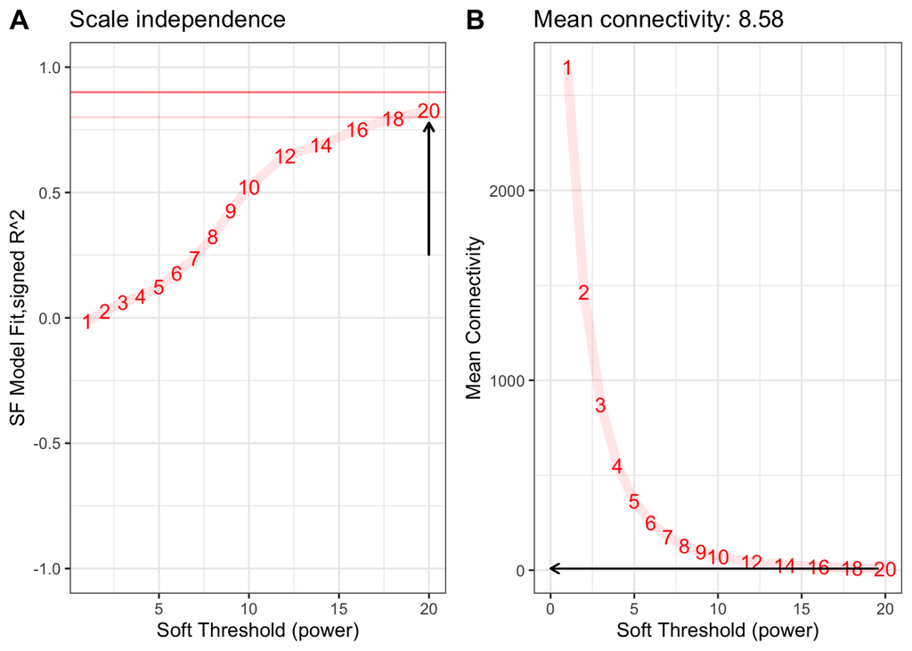

```r
idx <- min(which((-sign(sft$fitIndices[,3])*sft$fitIndices[,2]) > 0.90))
if(is.infinite(idx)){
  idx <- min(which((-sign(sft$fitIndices[,3])*sft$fitIndices[,2]) > 0.80))
  if(!is.infinite(idx)){
    st <- sft$fitIndices[idx,1]
  } else{
    idx <- which.max(-sign(sft$fitIndices[,3])*sft$fitIndices[,2])
    st <- sft$fitIndices[idx,1]
  }
} else{
  st <- sft$fitIndices[idx,1]
}

data.frame(Indices = sft$fitIndices[,1],
           sfApprox = -sign(sft$fitIndices[,3])*sft$fitIndices[,2]) %>%
  ggplot() +
  geom_hline(yintercept = 0.9, color = "red", alpha = 0.6) + # corresponds to R^2 cut-off of 0.9
  geom_hline(yintercept = 0.8, color = "red", alpha = 0.2) + # corresponds to R^2 cut-off of 0.8
  geom_line(aes(x = Indices, y = sfApprox), color = "red", alpha = 0.1, size = 2.5) +
  geom_text(mapping = aes(x = Indices, y = sfApprox, label = Indices), color = "red", size = 4) +
  ggtitle("Scale independence") +
  xlab("Soft Threshold (power)") +
  ylab("SF Model Fit,signed R^2") +
  xlim(1,20) +
  ylim(-1,1) + theme_bw() +
  geom_segment(aes(x = st, y = 0.25, xend = st, yend = sfApprox[idx]-0.05),
               arrow = arrow(length = unit(0.2,"cm")),
               size = 0.5)-> scale_independence_plot



data.frame(Indices = sft$fitIndices[,1],
           meanApprox = sft$fitIndices[,5]) %>%
  ggplot() +
  geom_line(aes(x = Indices, y = meanApprox), color = "red", alpha = 0.1, size = 2.5) +
  geom_text(mapping = aes(x = Indices, y = meanApprox, label = Indices), color = "red", size = 4) +
  xlab("Soft Threshold (power)") +
  ylab("Mean Connectivity") +theme_bw() +
  geom_segment(aes(x = st-0.4,
                   y = sft$fitIndices$mean.k.[idx],
                   xend = 0,
                   yend = sft$fitIndices$mean.k.[idx]),
               arrow = arrow(length = unit(0.2,"cm")),
               size = 0.4) +
  ggtitle(paste0("Mean connectivity: ",
                 round(sft$fitIndices$mean.k.[idx],2))) -> mean_connectivity_plot


cowplot::plot_grid(scale_independence_plot, mean_connectivity_plot, ncol = 2, align = "h", labels = c("A", "B"), label_size = plot_labeling_size) -> si_mc_plot
si_mc_plot
```

```r
modules.omics_X_Liver <- blockwiseModules(omics_data_host,
                                  power = st,
                                  networkType = "signed",
                                  TOMType = "signed",
                                  corType = assoc_measure,
                                  #maxPOutliers = 0.05,
                                  #deepSplit = 4, # Default 2
                                  minModuleSize = 20,           # 30
                                  #minCoreKME = 0.5,            # Default 0.5
                                  #minCoreKMESize = 2,          # Default minModuleSize/3,
                                  #minKMEtoStay = 0.5,          # Default 0.3
                                  #reassignThreshold = 0,       # Default 1e-6
                                  #mergeCutHeight = 0.2,        # Default 0.15
                                  #pamStage = pam_stage,
                                  #pamRespectsDendro = TRUE,
                                  #replaceMissingAdjacencies = TRUE,
                                  nThreads = 10,
                                  numericLabels = TRUE,
                                  saveTOMs = FALSE,
                                  saveTOMFileBase = "HOST_TOM",
                                  verbose = 1,
                                  maxBlockSize=8000)
```

```r
hubs <- chooseTopHubInEachModule(omics_data_host, modules.omics_X_Liver$colors, power = st, omitColors = "0")

stage2results_X_Liver <- list(modules = modules.omics_X_Liver,
                      hubs = hubs)

saveRDS(stage2results_X_Liver, "/Users/shashankgupta/Desktop/ImprovAFish/github/ImprovaFish/OmicsIntegration/stage2results_Transcriptomics_Liver.rds")
```

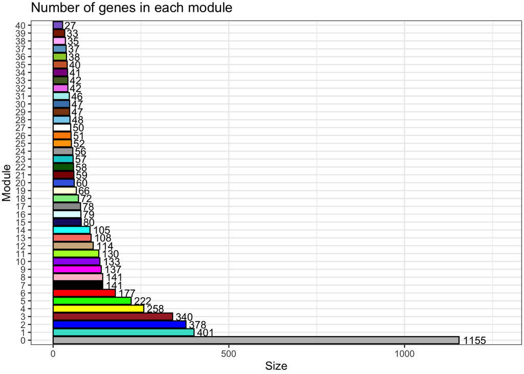

```r
# Convert labels to colors for plotting
merged_colors <- labels2colors(stage2results_X_Liver$modules$colors)
n_modules <- unique(merged_colors) %>% length()

samples_good <- sum(stage2results_X_Liver$modules$goodSamples) == length(stage2results_X_Liver$modules$goodSamples)
genes_good <- sum(stage2results_X_Liver$modules$goodGenes) == length(stage2results_X_Liver$modules$goodGenes)

ME_good <- sum(stage2results_X_Liver$modules$MEsOK) == length(stage2results_X_Liver$modules$MEsOK)
table(stage2results_X_Liver$modules$colors) %>%
  as.data.frame() %>%
  dplyr::rename(Module = Var1, Size = Freq) %>%
  dplyr::mutate(Module_color = labels2colors(as.numeric(as.character(Module)))) -> module_size

module_size %>%
  ggplot(aes(x = Module, y = Size, fill = Module)) +
  geom_col(color =  "#000000") +
  ggtitle("Number of genes in each module") +
  theme(legend.position = "none") +
  scale_fill_manual(values = setNames(module_size$Module_color,module_size$Module)) +
  geom_text(aes(label = Size),vjust = 0.5, hjust = -0.18, size = 3.5) +
  ylim(0, max(module_size$Size)*1.1) + theme_bw() +
  theme(plot.margin = margin(2, 2, 2, 2, "pt")) +
  coord_flip() -> module_size_barplot
module_size_barplot + theme(legend.position = "none") -> module_size_barplot
module_size_barplot
```

```r
MEs <- stage2results_X_Liver$modules$MEs
# Module correlation to other modules
MEs_R <- bicor(MEs, MEs, maxPOutliers = 0.05)

idx.r <- which(rownames(MEs_R) == "ME0")
idx.c <- which(colnames(MEs_R) == "ME0")
MEs_R_noME0 <- MEs_R[-idx.r, -idx.c]

MEs_R_noME0[upper.tri(MEs_R_noME0)] %>%
  as.data.frame() %>%
  dplyr::rename("correlation" = ".") %>%
  ggplot(aes(correlation)) +
  geom_histogram(bins = 20) +
  #geom_density() +
  xlim(-1, 1) +
  ggtitle(paste0(prefix,"ME correlation\n w/o ",prefix ,"ME0")) -> MEs_R_density

pheatmap::pheatmap(MEs_R_noME0, color = colorRampPalette(c("Blue", "White", "Red"))(100),
                   silent = T,
                   breaks = seq(-1,1,length.out = 101),
                   treeheight_row = 10,
                   treeheight_col = 10,
                   main = paste0(prefix,"ME correlation heatmap w/o ", prefix ,"ME0"),
                   labels_row = rep("", length(rownames(MEs_R))), #paste0(prefix, rownames(MEs_R)),
                   labels_col = rep("", length(colnames(MEs_R))) #paste0(prefix, colnames(MEs_R))
) -> MEs_R_Corr

cowplot::plot_grid(MEs_R_density, MEs_R_Corr$gtable, labels = c("D", "E"), label_size = plot_labeling_size, rel_widths = c(0.6, 1)) -> density_eigen

all(rownames(omics_data_host) == rownames(MEs))
```

```
## [1] TRUE
```

```r
dim(omics_data_host) %>% paste0(c(" samples", " genes"))
```

```
## [1] "144 samples" "5281 genes"
```

```r
kME <- bicor(omics_data_host, MEs, maxPOutliers = 0.05)
dim(kME) %>% paste0(c(" genes", " modules"))
```

```
## [1] "5281 genes" "41 modules"
```

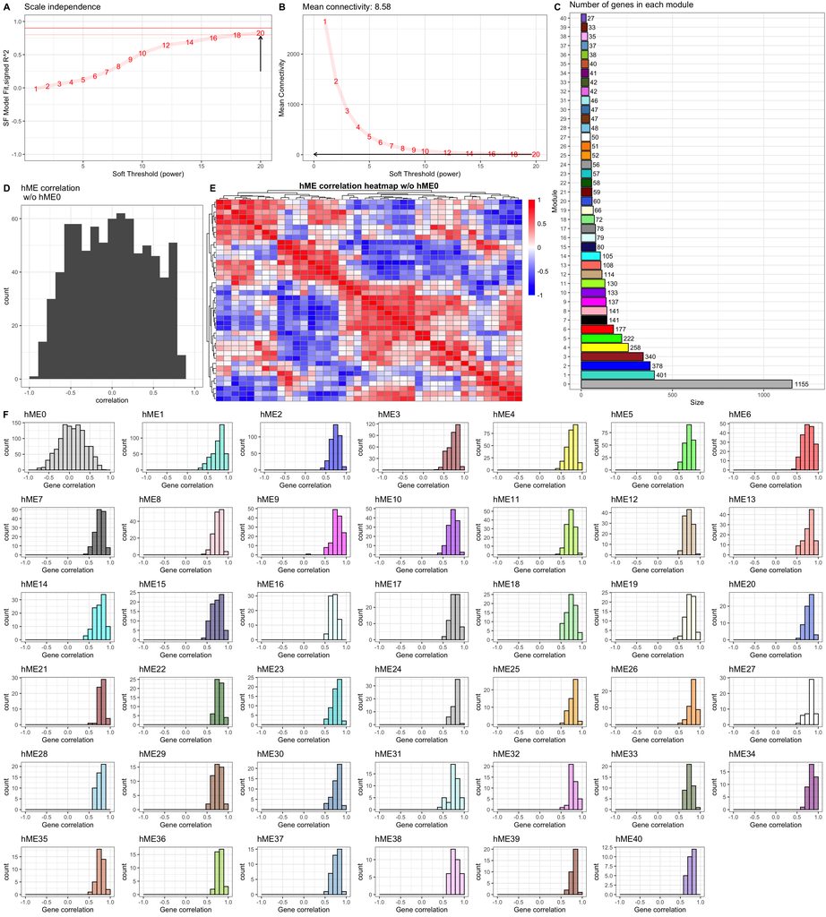

```r
# Corr within modules
corr_within_module <- function(omics_data_host, modules, module_x = 1){
  idx.omics_data_host <- which(modules$colors == module_x)
  idx.me <- which(colnames(modules$MEs) == paste0("ME",module_x))
  kME_x <- bicor(omics_data_host[,idx.omics_data_host], modules$MEs[,idx.me], maxPOutliers = 0.05)
  kME_x
}

ggplot.list <- list()

modules <-
  colnames(stage2results_X_Liver$modules$MEs)[colnames(stage2results_X_Liver$modules$MEs) %>% sub("ME", "", .) %>% as.numeric() %>% order()]

for(m in colnames(stage2results_X_Liver$modules$MEs)){
  h <- as.numeric(sub("ME","", m))
  data.frame(x = suppressWarnings(corr_within_module(omics_data_host = omics_data_host, modules = stage2results_X_Liver$modules, module_x = h))) %>%
    ggplot() +
    #geom_density(aes(x = x), fill = labels2colors(h), color = "black", alpha = 0.5) +
    geom_histogram(aes(x), fill = labels2colors(h), color = "black", alpha = 0.5, bins = 20) +
    xlim(-1, 1) +
    xlab("Gene correlation") +
    ggtitle(paste0(prefix,m)) -> da_plot

  ggplot.list[[m]] <- da_plot
}
ggplot.list <- ggplot.list[ggplot.list %>% names() %>% sub("ME", "", .) %>% as.numeric() %>% order()]
cowplot::plot_grid(plotlist = ggplot.list) -> density_all_plot

# comine to one plot
cowplot::plot_grid(si_mc_plot , density_eigen, ncol = 1, rel_heights = c(0.8,1)) -> part_1
cowplot::plot_grid(part_1, module_size_barplot, labels = c("", "C"), label_size = plot_labeling_size, rel_widths = c(1,0.5)) -> part_2
cowplot::plot_grid(part_2, density_all_plot, ncol = 1, rel_heights = c(0.8,1), labels = c("", "F"), label_size = plot_labeling_size) -> part_3
part_3
```

This code takes the results of a omics data and extracts the “hubs”, or most highly connected genes in the network, for each module.

```r
stage2results_X_Liver$hubs %>%
  as.data.frame() %>%
  dplyr::rename("gene_id" = ".") %>%
  tibble::rownames_to_column(var = "Module") -> top_genes

DT::datatable(top_genes)
```

|  | Module | gene_id |
| --- | --- | --- |
| 1 | 1 | ENSSSAG00000010140 |
| 2 | 2 | ENSSSAG00000052001 |
| 3 | 3 | ENSSSAG00000114648 |
| 4 | 4 | ENSSSAG00000073266 |
| 5 | 5 | ENSSSAG00000006445 |
| 6 | 6 | ENSSSAG00000119270 |
| 7 | 7 | ENSSSAG00000070543 |
| 8 | 8 | ENSSSAG00000042460 |
| 9 | 9 | ENSSSAG00000066273 |
| 10 | 10 | ENSSSAG00000066572 |

[output cut: 30 more lines]

### Statistical analysis

Linear regression analysis on the module eigengenes (principal components) from omics data, using the limma package. The sample information is loaded and the factors ‘Time’, ‘New_Diet’, and ‘Day’ are created based on the sample IDs. The design matrix for the regression is created using the ‘Day’ factor, and a linear model fit is performed on the transposed module eigengenes. The regression results are then run through an empirical Bayesian analysis. The topTable function is used to extract the regression statistics and create a data frame with the module names as the row names.

```r
#modules.omics_X_Liver.backup <- modules.omics_X_Liver
module_eigengenes <- modules.omics_X_Liver$MEs
all.equal(sample_info$ID_New, rownames(module_eigengenes))
```

```
## [1] TRUE
```

```r
sample_info %>%
  mutate(Time = factor(Time)) %>%
  mutate(New_Diet = factor(New_Diet)) %>%
  mutate(Day = ifelse(Time == "T1", paste0("T1_", New_Diet),
                      ifelse(Time == "T2", paste0("T2_", New_Diet), paste0("T3_", New_Diet)))) -> meta
DT::datatable(meta)
```

|  | Time | Diet | Tank_number | Sample_Type | Sample_Number | New_Diet | test | common | ID_New | Day |
| --- | --- | --- | --- | --- | --- | --- | --- | --- | --- | --- |
| T1_CTR_tk2_01 | T1 | mc1 | tk2 | Liver | 1 | CTR | False | T1_mc1_tk2_01 | T1_CTR_tk2_01 | T1_CTR |
| T1_CTR_tk2_03 | T1 | mc1 | tk2 | Liver | 3 | CTR | False | T1_mc1_tk2_03 | T1_CTR_tk2_03 | T1_CTR |
| T1_CTR_tk2_05 | T1 | mc1 | tk2 | Liver | 5 | CTR | False | T1_mc1_tk2_05 | T1_CTR_tk2_05 | T1_CTR |
| T1_CTR_tk2_07 | T1 | mc1 | tk2 | Liver | 7 | CTR | False | T1_mc1_tk2_07 | T1_CTR_tk2_07 | T1_CTR |
| T1_CTR_tk3_01 | T1 | mc2 | tk3 | Liver | 1 | CTR | False | T1_mc2_tk3_01 | T1_CTR_tk3_01 | T1_CTR |
| T1_CTR_tk3_03 | T1 | mc2 | tk3 | Liver | 3 | CTR | False | T1_mc2_tk3_03 | T1_CTR_tk3_03 | T1_CTR |
| T1_CTR_tk3_05 | T1 | mc2 | tk3 | Liver | 5 | CTR | False | T1_mc2_tk3_05 | T1_CTR_tk3_05 | T1_CTR |
| T1_CTR_tk3_07 | T1 | mc2 | tk3 | Liver | 7 | CTR | False | T1_mc2_tk3_07 | T1_CTR_tk3_07 | T1_CTR |
| T1_MC1_tk2_01 | T1 | ctr | tk2 | Liver | 1 | MC1 | False | T1_ctr_tk2_01 | T1_MC1_tk2_01 | T1_MC1 |
| T1_MC1_tk2_03 | T1 | ctr | tk2 | Liver | 3 | MC1 | False | T1_ctr_tk2_03 | T1_MC1_tk2_03 | T1_MC1 |

[output cut: 134 more lines]

```r
des_mat <- model.matrix(~ meta$Day)
fit <- limma::lmFit(t(module_eigengenes), design = des_mat)
fit <- limma::eBayes(fit)

stats_df <- limma::topTable(fit, number = ncol(module_eigengenes)) %>%
  tibble::rownames_to_column("module")

DT::datatable(stats_df)
```

|  | module | meta.DayT1_MC1 | meta.DayT1_MC2 | meta.DayT1_MN3 | meta.DayT2_CTR | meta.DayT2_MC1 | meta.DayT2_MC2 | meta.DayT2_MN3 | meta.DayT3_CTR | meta.DayT3_MC1 | meta.DayT3_MC2 | meta.DayT3_MN3 | AveExpr | F | P.Value | adj.P.Val |
| --- | --- | --- | --- | --- | --- | --- | --- | --- | --- | --- | --- | --- | --- | --- | --- | --- |
| 1 | ME39 | -0.020836043553525 | -0.0177406232147886 | -0.0165571743413245 | -0.0314759497415507 | -0.0334807862826689 | -0.0202764318015461 | -0.0244564913117997 | 0.162875076950723 | 0.122910945381384 | 0.121661467100266 | 0.155485459783272 | -3.74049749507499e-18 | 65.9579318436357 | 1.15205918467896e-49 | 4.72344265718374e-48 |
| 2 | ME29 | -0.0207393063098178 | -0.00238706720132015 | -0.00845255874155377 | 0.161802553506652 | 0.163834017663923 | 0.154331159637365 | 0.166263858078886 | 0.146868619389218 | 0.137917430166544 | 0.142917929787653 | 0.161265388561059 | 2.68641204960297e-18 | 64.4975611322248 | 4.18734216082067e-49 | 8.58405142968238e-48 |
| 3 | ME17 | 0.00472152592274986 | -0.00916312500099405 | 0.0155204923967277 | -0.178123623042892 | -0.191211087736801 | -0.169304106261897 | -0.172958941233588 | -0.0851818372218584 | -0.103901420689201 | -0.133052869283739 | -0.110911728696391 | 5.21866410280566e-18 | 50.5184177906234 | 3.85402424410637e-43 | 5.26716646694537e-42 |
| 4 | ME36 | -2.08256171789014e-05 | 0.0313217184408757 | 0.0104967855274683 | 0.198498996415056 | 0.201610259512636 | 0.174818292820126 | 0.183489724026415 | 0.0684532807075722 | 0.0839847206592322 | 0.0816927094909714 | 0.083207556708987 | 9.44385267325395e-18 | 45.2331511275123 | 1.53228782876697e-40 | 1.57059502448614e-39 |
| 5 | ME35 | -0.0429246791062355 | -0.00749001745644753 | -0.0263632638225994 | 0.0930290865763424 | 0.0957551365179719 | 0.0666319212464946 | 0.0903913397878899 | 0.150813933398122 | 0.155818781814266 | 0.154840444845023 | 0.169785063699212 | 2.57799183235442e-18 | 41.4145493591934 | 1.62924063330429e-38 | 1.33597731930952e-37 |
| 6 | ME14 | -0.00231418595040635 | -0.0114378936514131 | -0.000228107727450675 | -0.157505207243246 | -0.172994529390068 | -0.146152156675568 | -0.145824747290392 | 0.0152565048726894 | 0.00306446798865236 | -0.0215079579155631 | 0.00666061130439004 | -2.36416307055867e-18 | 40.2116986061353 | 7.57443660395519e-38 | 5.17586501270271e-37 |
| 7 | ME13 | 0.0574329814614221 | 0.015600188989782 | 0.0442963555157665 | 0.0823551078148981 | 0.0805481448014057 | 0.0762517824980181 | 0.0885974931710977 | -0.0941376370684679 | -0.0811604569187467 | -0.0740096578320362 | -0.103603362380097 | -5.49630267996124e-18 | 36.6716324770395 | 8.56501907113473e-36 | 5.01665402737891e-35 |
| 8 | ME18 | 0.00447749599823838 | 0.00633658583802562 | 0.0287233055694321 | -0.00652410712771952 | -0.0110605801137029 | -0.021878270012538 | -0.0254761393779664 | -0.145320835469132 | -0.152605555606882 | -0.162238665957033 | -0.15494643292875 | -2.37922143406541e-18 | 35.2193967521416 | 6.55778416553336e-35 | 3.36086438483585e-34 |
| 9 | ME31 | 0.0105446362378323 | 0.0387813314355269 | 0.0229731551420413 | 0.0689183906326645 | 0.0658557326543245 | 0.0513845032165953 | 0.0462552400204982 | -0.105006155348632 | -0.104361216131093 | -0.117415538851073 | -0.0980376306955123 | -3.35801506200372e-18 | 30.2664749288936 | 1.09632810381845e-31 | 4.99438358406185e-31 |
| 10 | ME15 | -0.00399139279238669 | 0.0163252705958527 | 0.0173737879892938 | 0.133547732930201 | 0.135081535952013 | 0.112820972540684 | 0.117396922597834 | -0.042814078152221 | -0.0484174388054182 | -0.0420265820728659 | -0.0339806502082769 | 2.24369616250472e-18 | 29.0615934350037 | 7.55383675828741e-31 | 3.09707307089784e-30 |

[output cut: 31 more lines]

Let’s make plot of module 17

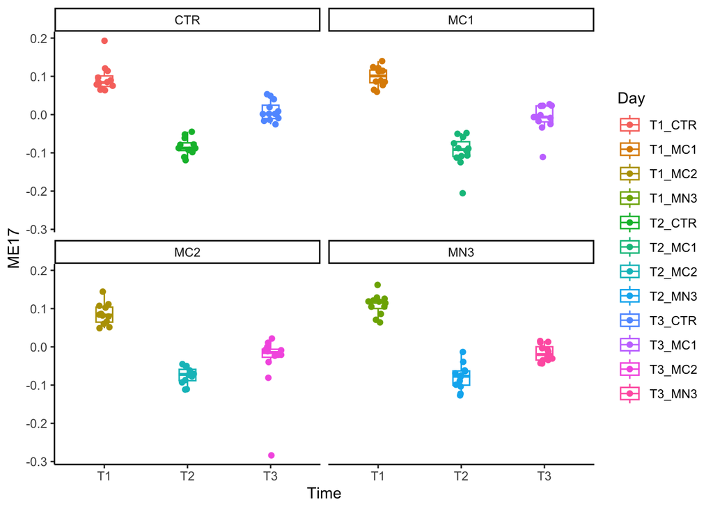

```r
module_df <- module_eigengenes %>%
  tibble::rownames_to_column("ID_New") %>%
  dplyr::inner_join(meta %>%
                      dplyr::select(ID_New, Day, Time, New_Diet),
                    by = c("ID_New" = "ID_New"))


ggplot(module_df, aes(x = Time, y = ME17, color = Day)) +
  geom_boxplot(width = 0.2, outlier.shape = NA) +
  ggforce::geom_sina(maxwidth = 0.3) +
  theme_classic() + facet_wrap("New_Diet")
```

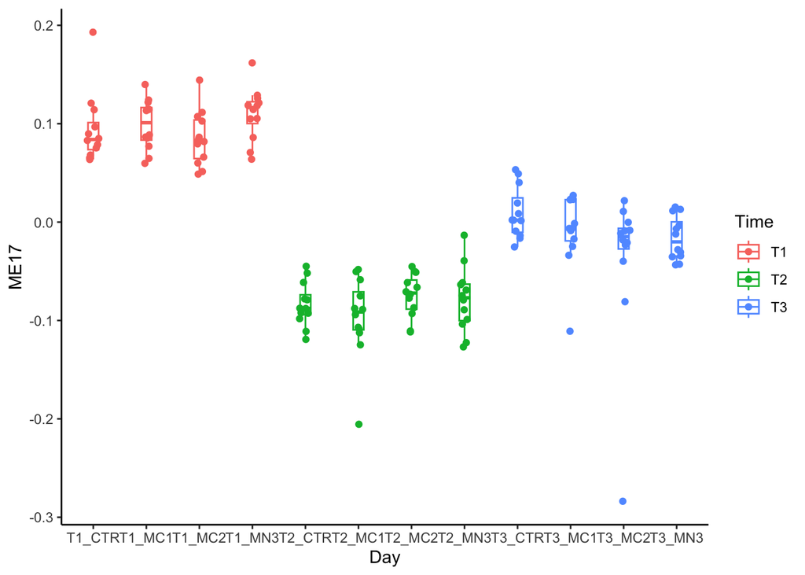

```r
ggplot(module_df, aes(x = Day, y = ME17, color = Time)) +
  geom_boxplot(width = 0.2, outlier.shape = NA) +
  ggforce::geom_sina(maxwidth = 0.3) +
  theme_classic()
```

```r
gene_module_key <- tibble::enframe(modules.omics_X_Liver$colors, name = "gene", value = "module") %>%
  # Let's add the `ME` part so its more clear what these numbers are and it matches elsewhere
  dplyr::mutate(module = paste0("ME", module))

# gene_module_key %>%
#   dplyr::filter(module == "ME21")
DT::datatable(gene_module_key)
```

|  | gene | module |
| --- | --- | --- |
| 1 | ENSSSAG00000103407 | ME2 |
| 2 | ENSSSAG00000047554 | ME5 |
| 3 | ENSSSAG00000086900 | ME18 |
| 4 | ENSSSAG00000024596 | ME6 |
| 5 | ENSSSAG00000107383 | ME5 |
| 6 | ENSSSAG00000052128 | ME0 |
| 7 | ENSSSAG00000056486 | ME0 |
| 8 | ENSSSAG00000056522 | ME7 |
| 9 | ENSSSAG00000015684 | ME16 |
| 10 | ENSSSAG00000056816 | ME0 |

[output cut: 5271 more lines]

### Functional analysis

The code in R connects to the AnnotationHub package and selects OrgDb annotations for the species “Salmo salar”. It creates two objects, SsalOrg, by subsetting and extracting the desired annotations from the ah object.

```r
# get OrgDb from AnnotationHub
ah <- AnnotationHub()
SsalOrg <- subset(ah, ah$species == "Salmo salar" & ah$rdataclass=="OrgDb")
SsalOrg <- ah[["AH96017"]]
```

This script performs gene enrichment analysis on multiple modules of genes. The modules of genes are generated from omics data, and the gene annotations are read from a csv file. The probes from the omics data are matched with the gene IDs from the annotations, and the LocusLink IDs are obtained. The unique modules are then selected, and their LocusLink IDs are written into separate text files. Finally, gene ontology (GO) and KEGG pathway analysis are performed for each module using the enrichGO and enrichKEGG functions, respectively. The results are then visualized using the dotplot function.

```r
moduleLabels <- modules.omics_X_Liver$colors
moduleColors <- labels2colors(modules.omics_X_Liver$colors)
table(moduleColors)
```

```
## moduleColors
##          black           blue          brown           cyan      darkgreen
##            141            378            340            105             58
##       darkgrey    darkmagenta darkolivegreen     darkorange        darkred
##             56             41             42             51             59
##  darkturquoise          green    greenyellow           grey         grey60
##             57            222            130           1155             78
##      lightcyan     lightgreen    lightyellow        magenta  mediumpurple3
##             79             72             66            137             27
##   midnightblue         orange     orangered4  paleturquoise           pink
##             80             52             33             46            141
##          plum1         purple            red      royalblue    saddlebrown
##             35            133            177             60             47
##         salmon        sienna3        skyblue       skyblue3      steelblue
##            108             40             48             37             47
##            tan      turquoise         violet          white         yellow
##            114            401             42             50            258
##    yellowgreen
##             38
```

```r
# table(moduleLabels)
# table(moduleColors, moduleLabels)

MEs <- modules.omics_X_Liver$MEs
geneTree <- modules.omics_X_Liver$dendrograms[[1]]


#https://gitlab.com/garethgillard/ssalv3annotation
annot1 <- read.csv("/Users/shashankgupta/Desktop/ImprovAFish/github/Input/Salmo_salar-GCA_905237065.2_gene_annotations.csv", header = TRUE)

probes <- colnames(omics_data_host)
probes2annot <- match(probes, annot1$gene_id)
allLLIDs <- annot1$v2.gene_id.NCBI[probes2annot]

intModules <- unique(moduleColors)
dir.create("/Users/shashankgupta/Desktop/ImprovAFish/github/ImprovaFish/Transcriptomics/intermediate_files/Liver")
setwd("/Users/shashankgupta/Desktop/ImprovAFish/github/ImprovaFish/Transcriptomics/intermediate_files/Liver")
for (module in intModules)
{
  # Select module probes
  modGenes = (moduleColors==module)
  # Get their entrez ID codes
  modLLIDs = allLLIDs[modGenes]
  # Write them into a file
  fileName = paste("LocusLinkIDs-", module, ".txt", sep="");
  write.table(as.character(modLLIDs), file = fileName, row.names = FALSE, col.names = FALSE)
}

fileName = paste("LocusLinkIDs-all.txt", sep="");
write.table(as.character(allLLIDs), file = fileName, row.names = FALSE, col.names = FALSE)

#table(moduleColors)
list_names <- unique(moduleColors)
all.df <- read.table("LocusLinkIDs-all.txt")
all.df$V1 <- as.character(all.df$V1)
for (i in list_names){
  assign(paste(i,"_df", sep=""), read.table(paste0("LocusLinkIDs-",i,".txt")))
  assign(paste("resGO_",i, sep=""), enrichGO(gene = get(paste0(i,"_df"))$V1, ont = "BP", universe = all.df$V1, OrgDb = "SsalOrg", pvalueCutoff  = 0.05,qvalueCutoff  = 0.05))
  assign(paste("resGO_dotplot_",i, sep=""), dotplot(get(paste0("resGO_",i))))
  assign(paste("resKEGG_",i, sep=""), enrichKEGG(gene = get(paste0(i,"_df"))$V1, universe = all.df$V1,  organism = "sasa", pvalueCutoff = 0.05, qvalueCutoff  = 0.05))
  assign(paste("resKEGG_dotplot_",i, sep=""), dotplot(get(paste0("resKEGG_",i))))
}
```

```r
# save all the plots
setwd("/Users/shashankgupta/Desktop/ImprovAFish/github/ImprovaFish/Transcriptomics/intermediate_files/Liver")
resGO_dot_plots <- ls(pattern="resGO_dotplot_*")

# saving PNG
for (i in 1:length(resGO_dot_plots)) {
  tryCatch({
    png(paste0(resGO_dot_plots[i], ".png"))
    print(get(resGO_dot_plots[i]))
    dev.off()
  }, error = function(e) {
    #print(paste("Error printing", resGO_dot_plots[i], ":", e))
    file.remove(paste0(resGO_dot_plots[i], ".png"))
  })
}
```

```r
setwd("/Users/shashankgupta/Desktop/ImprovAFish/github/ImprovaFish/Transcriptomics/intermediate_files/Liver")
resKEGG_dot_plots <- ls(pattern="resKEGG_dotplot_*")

# saving PNG
for (i in 1:length(resKEGG_dot_plots)) {
  tryCatch({
    png(paste0(resKEGG_dot_plots[i], ".png"))
    print(get(resKEGG_dot_plots[i]))
    dev.off()
  }, error = function(e) {
   # print(paste("Error printing", resKEGG_dot_plots[i], ":", e))
    file.remove(paste0(resKEGG_dot_plots[i], ".png"))
  })
}
```

```r
setwd("/Users/shashankgupta/Desktop/ImprovAFish/github/ImprovaFish/Transcriptomics/intermediate_files/Liver")
resKEGG_dot_plots <- ls(pattern="resKEGG_dotplot_*")

# saving PNG
for (i in 1:length(resKEGG_dot_plots)) {
  tryCatch({
    png(paste0(resKEGG_dot_plots[i], ".png"))
    print(get(resKEGG_dot_plots[i]))
    dev.off()
    knitr::include_graphics(paste0(resKEGG_dot_plots[i], ".png"))
  }, error = function(e) {
    # print(paste("Error printing", resKEGG_dot_plots[i], ":", e))
    file.remove(paste0(resKEGG_dot_plots[i], ".png"))
  })
}
```